# Block 3. Beyond the mean: landscape pattern as covariates

multiScaleR workshop, The Wildlife Society Annual Conference, November 4, 2026

Author

Bill Peterman and Joseph Drake

**TipStart fresh**

Restart R before you begin (RStudio: **Session > Restart R**), then run the setup chunk below. It reloads the data and the three fits you saved at the end of Block 2, and the fresh session returns the memory Block 2 used.

```r
source("00_setup.R")
if (!exists("opt_cat")) load_checkpoint("block2")   # opt_cat, opt_chip_screen, opt_deer
```

Block 2 asked how much urbanization surrounds a camera. That is a kernel-weighted mean, and it is often the right question. But species also respond to how a landscape is put together: how much edge there is, how many cover types meet, how clumped the forest is, or how variable a continuous surface is. Version 0.7 of `multiScaleR` treats each of these as a covariate with its own estimated scale. This block works through two examples where the answer changes: opossum, where landscape configuration explains visits that urbanization does not, and deer, where the variability of urbanization beats its average.

# 1 Start the slow step now

The chunk below computes four land-cover metrics at every cell of the study area, about 3 million cells, which takes a minute or two. Start it now and read on while it runs. The next section explains the functions it uses, and the opossum section looks at the maps.

```r
lc_view <- crop(landcover, pred_ext)
metric_maps <- kernel_scale.raster(
  lc_view,
  scale_vars = msr_vars(
    `Edge density (m/ha)` = landscape_var("landcover", metric = "ed",    radius = 500),
    `Aggregation index`   = landscape_var("landcover", metric = "ai",    radius = 500),
    `Shannon diversity`   = landscape_var("landcover", metric = "shdi",  radius = 500),
    `Forest cover (%)`    = landscape_var("landcover", metric = "pland", radius = 500, class = 4)
  ),
  verbose = FALSE
)                                                             # about 1.5 min
```

# 2 From raster layers to covariates

Until now, each raster layer became one kernel-weighted covariate with the same name. With landscape metrics, one layer can yield several covariates: the same land-cover map gives forest percentage, edge density, and diversity, each at its own scale. `msr_vars()` names those covariates explicitly and says how each is derived.

```r
example_vars <- msr_vars(
  urb_mean     = kernel_var("urb_pca"),
  urb_sq       = surface_var("urb_pca", metric = "sq", weighted = TRUE),
  forest_pland = landscape_var("landcover", metric = "pland", class = 4),
  lc_ed_500    = landscape_var("landcover", metric = "ed", radius = 500)
)
example_vars
```

```
multiScaleR variable specifications:
    covariate    source      type metric radius optimize weighted     base
     urb_mean   urb_pca    kernel   <NA>     NA     TRUE    FALSE 2.718282
       urb_sq   urb_pca   surface     sq     NA     TRUE     TRUE 2.718282
 forest_pland landcover landscape  pland     NA     TRUE    FALSE 2.718282
    lc_ed_500 landcover landscape     ed    500    FALSE    FALSE 2.718282
 classes_max class
          NA    NA
          NA    NA
          NA     4
          NA    NA
```

**How to read this output:** each row is a model covariate. `source` is the raster layer it comes from; two covariates come from `urb_pca` and two from `landcover`. `type` says how it is computed. A `radius` of `NA` with `optimize = TRUE` means the scale will be estimated; `lc_ed_500` has a fixed 500 m radius and no scale parameter. `weighted = TRUE` marks the kernel-weighted surface metric. `class` names the focal class for class-level metrics (4 is forest), and `base` sets the logarithm base for the diversity and entropy metrics.

| Specification | Raster | Computes | Scale parameter |
| --- | --- | --- | --- |
| `kernel_var()` | Continuous or binary | Distance-weighted mean | sigma (smooth) |
| `landscape_var()` | Categorical (integer classes) | Landscape metric within a circular buffer | radius (hard edge), or fixed |
| `surface_var()` | Continuous | Surface texture: roughness, shape, slope | radius (hard edge), or sigma with `weighted = TRUE` |

`landscape_var()` supports 25 metrics in five families, all matching the FRAGSTATS definitions used by the `landscapemetrics` package. The ones we use here:

| Code | Metric | Family | Reads as |
| --- | --- | --- | --- |
| `pland` | Percentage of landscape (needs `class`) | Class-level | How much forest is in the buffer |
| `ed` | Edge density (m/ha) | Edge | How much boundary between classes |
| `ai` | Aggregation index | Adjacency | How clumped the classes are |
| `shdi` | Shannon diversity | Composition | How many classes, how evenly mixed |
| `ent`, `mutinf` | Marginal entropy, mutual information | Information theory | Composition and configuration, separated |
| `contag` | Contagion | Adjacency | Overall clumping across class pairs |

See `vignette("landscape_metric_covariates", package = "multiScaleR")` for the full table and `vignette("surface_metric_covariates", package = "multiScaleR")` for the surface metrics.

One link back to Block 2: a kernel-weighted mean of a 0/1 layer is a distance-weighted proportion, the kernel analog of `pland`. The appendix fits one for cats; a plain developed layer beats the PCA index by about 5 AICc at a similar 50 to 60 m scale.

# 3 Opossum: categorical landscape metrics

Virginia opossums are generalists often described as edge species. Start with the Block 2 question.

```r
ki_opp_pca <- kernel_prep(cam_sf, urb, max_D = 2000, kernel = "gaussian",
                          store_cell_data = FALSE, verbose = FALSE)
dat_opp_pca <- data.frame(visits = site_data$opossum, n_weeks = site_data$n_weeks,
                          ki_opp_pca$kernel_dat)
mod_opp_pca <- glm.nb(visits ~ urb_pca + offset(log(n_weeks)), data = dat_opp_pca)
opt_opp_pca <- multiScale_optim(mod_opp_pca, ki_opp_pca)
```

```
Optimization complete

 WARNING!!!
 The standard error of one or more `sigma` estimates is >= 50% of the estimated mean value.
 Carefully assess whether or not this variable is meaningful in your analysis and interpret with caution.
```

```r
summary(opt_opp_pca)$opt_scale
```

```
            Mean       SE 2.5%    97.5%
urb_pca 153.9498 121.4345   30 393.3706
```

```r
coef(summary(opt_opp_pca$opt_mod))
```

```
              Estimate Std. Error   z value     Pr(>|z|)
(Intercept) -0.9035564  0.1056822 -8.549746 1.233600e-17
urb_pca      0.2140939  0.1046538  2.045735 4.078247e-02
```

**How to read this output:** the scale is poorly defined (the standard error is nearly as large as sigma) and the urbanization effect is weak. By this analysis alone, opossums barely respond to urbanization. Hold that thought.

## 3.1 Look before you model: metric maps at a fixed radius

`kernel_scale.raster()` computes a landscape metric at every cell without a fitted model; that is what the chunk at the top of this block did. Maps at one radius show what each metric picks out before you commit to one.

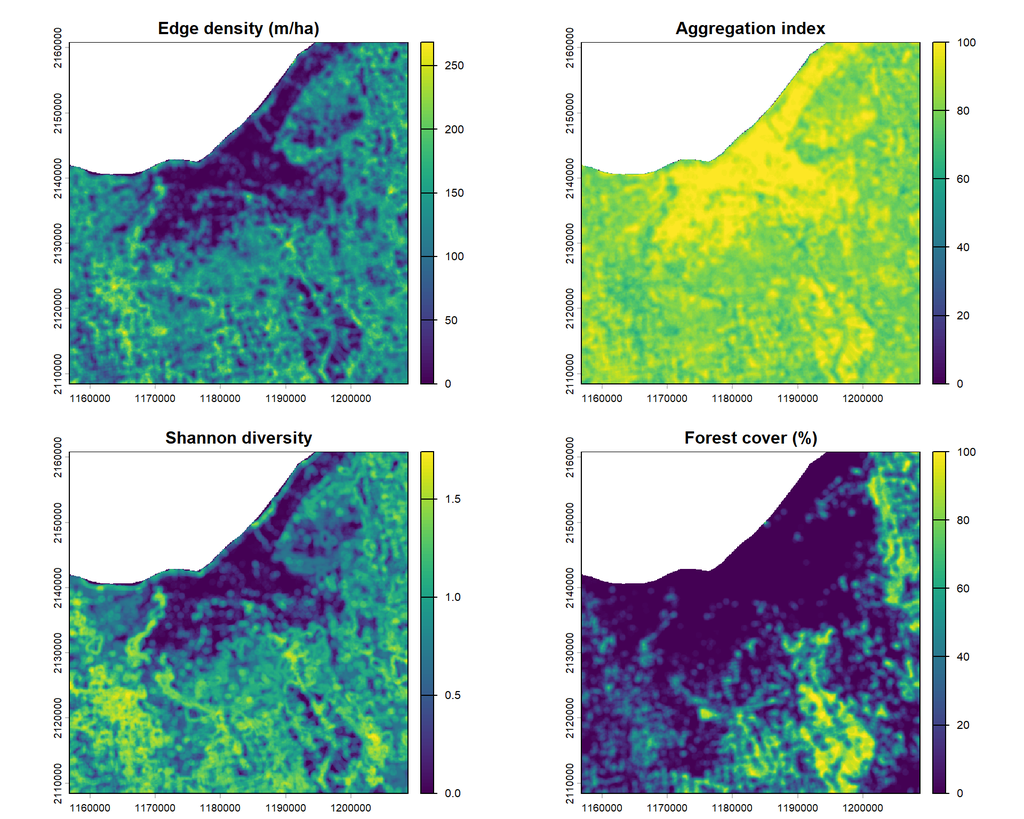

Figure 1: Four land-cover metrics computed within 500 m of every cell. Edge density and aggregation index are near mirror images; Shannon diversity tracks them; forest cover follows the park system.

```r
plot(metric_maps, nc = 2)
```

**How to read these maps:** bright cells score high. Edge density is high where many small patches meet, which is also where aggregation is low, so the two maps are close to inverses. Diversity rises wherever several classes share a buffer. Forest cover is highest along the river valleys. Metrics that look alike on a map will be nearly collinear in a model.

## 3.2 Screen the candidates at the cameras

Before optimizing, compute each candidate at a fixed radius at the cameras and check how much they overlap.

```r
screen_vars <- msr_vars(
  ed     = landscape_var("landcover", metric = "ed",     radius = 500),
  ai     = landscape_var("landcover", metric = "ai",     radius = 500),
  shdi   = landscape_var("landcover", metric = "shdi",   radius = 500),
  ent    = landscape_var("landcover", metric = "ent",    radius = 500, base = 2),
  mutinf = landscape_var("landcover", metric = "mutinf", radius = 500, base = 2),
  forest = landscape_var("landcover", metric = "pland",  radius = 500, class = 4)
)
ki_screen <- kernel_prep(cam_sf, landcover, max_D = 560, scale_vars = screen_vars,
                         verbose = FALSE)
round(cor(ki_screen$kernel_dat), 2)
```

```
          ed    ai  shdi   ent mutinf forest
ed      1.00 -1.00  0.89  0.89   0.62  -0.51
ai     -1.00  1.00 -0.87 -0.87  -0.58   0.50
shdi    0.89 -0.87  1.00  1.00   0.90  -0.56
ent     0.89 -0.87  1.00  1.00   0.90  -0.57
mutinf  0.62 -0.58  0.90  0.90   1.00  -0.55
forest -0.51  0.50 -0.56 -0.57  -0.55   1.00
```

**How to read this matrix:** edge density and aggregation index correlate at about -1, and Shannon diversity and marginal entropy at 1: within a buffer they measure the same thing, so fitting both, or comparing them as if they were distinct hypotheses, adds nothing. Mutual information (configuration after composition is removed) and forest cover overlap less with edge density. We carry forward one metric per idea: forest cover for amount, edge density for configuration.

## 3.3 Optimize the edge-density radius

```r
ki_opp_ed <- kernel_prep(cam_sf, landcover, max_D = 2000, kernel = "gaussian",
                         scale_vars = msr_vars(lc_ed = landscape_var("landcover", metric = "ed")),
                         verbose = FALSE)
dat_opp_ed <- data.frame(visits = site_data$opossum, n_weeks = site_data$n_weeks,
                         ki_opp_ed$kernel_dat)
mod_opp_ed <- glm.nb(visits ~ lc_ed + offset(log(n_weeks)), data = dat_opp_ed)
system.time(opt_opp_ed <- multiScale_optim(mod_opp_ed, ki_opp_ed))
```

```
Optimization complete
```

```
   user  system elapsed
  28.87    4.47   68.17
```

```r
summary(opt_opp_ed)
```

```
Call:
multiScale_optim(fitted_mod = mod_opp_ed, kernel_inputs = ki_opp_ed)


Kernel used:
gaussian

***** Optimized Scale of Effect *****

          Mean SE 2.5% 97.5%
lc_ed 555.4919 NA   NA    NA

Radius (map units) for: lc_ed.
Hard-radius effects change in steps as cells enter the buffer. Hessian standard errors are omitted; use `summary(x, profile = TRUE)` for profile-likelihood limits.


  ====================================

***** Optimized Scale of Effect -- Distance *****
Radius (map units) of each hard-radius covariate

        Mean 2.5% 97.5%
lc_ed 555.49   NA    NA


  ====================================

 *****     Fitted Model Summary     *****


Call:
glm.nb(formula = visits ~ lc_ed + offset(log(n_weeks)), data = data,
    init.theta = 0.5531020599, link = log)

Coefficients:
            Estimate Std. Error z value Pr(>|z|)
(Intercept)  -1.0313     0.1005 -10.265  < 2e-16 ***
lc_ed         0.5516     0.1019   5.415 6.11e-08 ***
---
Signif. codes:  0 '***' 0.001 '**' 0.01 '*' 0.05 '.' 0.1 ' ' 1
```

[output cut: 8 more lines]

```

              Theta:  0.5531
          Std. Err.:  0.0663

 2 x log-likelihood:  -1032.6580


***** Follow-up recommendation *****
Recommended `max_D`: 2000
Recommended starting `sigma` values:
   lc_ed
555.4919

Action:
Use the optimized parameters as efficient starting values if refitting.
```

**How to read the `summary()` output for a hard radius:** the scale is now a buffer radius, not a kernel sigma, and it has no standard error. As the radius grows, cells enter the buffer one ring at a time, so the likelihood changes in small steps, and a Hessian-based standard error computed on a staircase is meaningless. The effective distance for a hard radius is the radius itself. Get the interval from the profile likelihood instead:

```r
summary(opt_opp_ed, profile = TRUE)$opt_scale
```

```
          Mean SE   2.5%    97.5%
lc_ed 555.4919 NA 436.64 957.8563
```

```
Profiling 'lc_ed' (1 of 1)...
Done.
```

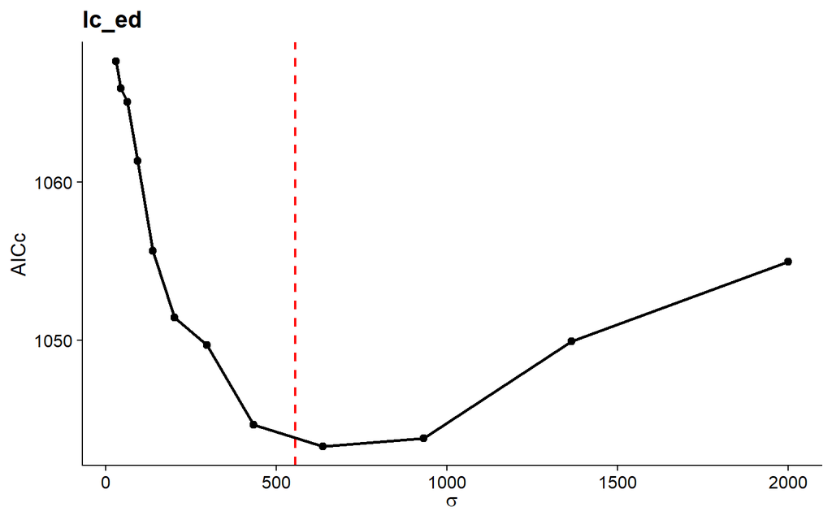

Figure 2: AICc across buffer radius for opossum edge density: a broad valley from roughly 450 to 950 m. The dashed line marks the optimized radius. The axis is labeled sigma; for a hard-radius covariate, read it as the radius.

```r
plot(profile_sigma(opt_opp_ed, n_pts = 12))
```

Edge density within about 555 m (profile 95% CI 437 to 958 m) predicts opossum visits strongly: each SD of edge density multiplies visits by about 1.7. Moll et al. (2020) placed the opossum’s scale of maximal effect for urbanization at 249 m, with a wide interval (70 to 1427 m).

## 3.4 Amount or configuration?

Edge density rises as forest is broken up, so is this really a forest-amount effect in disguise? Fit forest cover alone, then both together, each with its own radius.

```r
amount_vars <- msr_vars(
  forest_pland = landscape_var("landcover", metric = "pland", class = 4),
  lc_ed        = landscape_var("landcover", metric = "ed")
)
ki_opp_amt <- kernel_prep(cam_sf, landcover, max_D = 2000, kernel = "gaussian",
                          scale_vars = amount_vars, verbose = FALSE)
dat_opp_amt <- data.frame(visits = site_data$opossum, n_weeks = site_data$n_weeks,
                          ki_opp_amt$kernel_dat)

mod_opp_forest <- glm.nb(visits ~ forest_pland + offset(log(n_weeks)), data = dat_opp_amt)
opt_opp_forest <- multiScale_optim(mod_opp_forest, ki_opp_amt)            # about 30 s
```

```
Optimization complete
```

```r
mod_opp_both <- glm.nb(visits ~ forest_pland + lc_ed + offset(log(n_weeks)), data = dat_opp_amt)
if (run_slow_fits) {
  opt_opp_both <- multiScale_optim(mod_opp_both, ki_opp_amt)              # about 1.5 min
} else {
  opt_opp_both <- readRDS("checkpoints/block3.rds")$opt_opp_both          # our fit from that call
}
```

```
Optimization complete
```

**TipThe two joint fits load from our checkpoint**

Two fits in this block take about 1.5 minutes each: this one and the deer mean + roughness model. By default the notebook loads our saved fits, produced by the same call on the same data, so the block keeps moving. To refit them live, run `run_slow_fits <- TRUE` after the setup chunk. The saved fits were lightened (see the checkpoint section), so they can be summarized and compared but not profiled.

```r
summary(opt_opp_both)$opt_scale
```

```
                 Mean SE 2.5% 97.5%
forest_pland 457.2616 NA   NA    NA
lc_ed        748.8302 NA   NA    NA
```

```r
coef(summary(opt_opp_both$opt_mod))
```

```
               Estimate Std. Error    z value     Pr(>|z|)
(Intercept)  -1.0376461  0.1000907 -10.367060 3.501321e-25
forest_pland -0.1333309  0.1097083  -1.215322 2.242432e-01
lc_ed         0.4801335  0.1096264   4.379725 1.188292e-05
```

```r
aic_tab(list(opt_opp_pca, opt_opp_forest, opt_opp_ed, opt_opp_both),
        mod_names = c("Urbanization (kernel mean)", "Forest cover", "Edge density",
                      "Forest cover + edge density"))
```

```
Model selection based on AICc:

                            K    AICc Delta_AICc AICcWt Cum.Wt      LL
Edge density                4 1040.86       0.00   0.82   0.82 -516.33
Forest cover + edge density 6 1043.87       3.02   0.18   1.00 -515.73
Forest cover                4 1055.11      14.25   0.00   1.00 -523.46
Urbanization (kernel mean)  4 1064.78      23.92   0.00   1.00 -528.29
```

**How to read the `aic_tab()` output:** `K` counts every estimated parameter, including each scale and the negative binomial dispersion, and `AICc` corrects AIC for sample size. `Delta_AICc` is the distance from the best model; a difference above about 2 is meaningful, and above 4 is strong. `aic_tab()` refuses to compare models fit to different cameras, so every comparison in this block uses all 207. In the joint model, edge density keeps a strong positive effect while forest cover shrinks toward zero and loses significance. Edge density alone is the best model; adding forest cover costs more in parameters than it returns in fit. Urbanization, the covariate that looked weak at the start, is far behind.

**NoteInterpreting the opossum result**

Opossums track how the landscape is arranged, not how urban it is. Within about half a kilometer of a camera, more boundary between land-cover types means more opossum visits, whatever the total amount of forest. That fits a generalist that forages along forest edges, lawns, and wetland margins. A study that measured only urbanization, or only forest cover, would have missed it.

**WarningFragile metrics and the sample-size guard**

Some metrics are undefined in some buffers: contagion needs at least two classes, interspersion (`iji`) needs three, and `clumpy` is `NA` where the focal class is absent or fills the whole buffer. At small radii many cameras sit in a single class. Since version 0.7.1, `multiScale_optim()` rejects any candidate scale that would make the covariate undefined at a camera, so every likelihood is compared on the same sample. Confirm with `diagnostics(opt)$sample_size`, and screen fragile metrics at a few fixed radii before optimizing them.

```r
diagnostics(opt_opp_ed)$sample_size[c("fitted_n", "prepared_n")]
```

```
$fitted_n
[1] 207

$prepared_n
[1] 207
```

# 4 Deer: continuous surface metrics

In Block 2, deer responded positively to mean urbanization at a sigma of about 750 m. The PCA index sits on its minimum in forest and rises only where development appears, so a neighborhood can have a moderate mean in two ways: a uniform, lightly developed suburb, or a mosaic of forest and dense development. Surface metrics tell those apart. `sq` is the standard deviation of the surface within the neighborhood, its roughness.

With `weighted = TRUE`, each cell’s contribution to the roughness is weighted by the same Gaussian kernel used for means, and sigma is estimated with a smooth likelihood and a standard error.

```r
ki_deer_sq <- kernel_prep(cam_sf, urb, max_D = 3000, kernel = "gaussian",
                          scale_vars = msr_vars(urb_sq = surface_var("urb_pca", metric = "sq",
                                                                     weighted = TRUE)),
                          verbose = FALSE)
dat_deer_sq <- data.frame(visits = site_data$deer, n_weeks = site_data$n_weeks,
                          ki_deer_sq$kernel_dat)
mod_deer_sq <- glm.nb(visits ~ urb_sq + offset(log(n_weeks)), data = dat_deer_sq)
opt_deer_sq <- multiScale_optim(mod_deer_sq, ki_deer_sq)                  # about 30 s
```

```
Optimization complete
```

```r
summary(opt_deer_sq)
```

```
Call:
multiScale_optim(fitted_mod = mod_deer_sq, kernel_inputs = ki_deer_sq)


Kernel used:
gaussian

***** Optimized Scale of Effect *****

           Mean       SE     2.5%    97.5%
urb_sq 300.4116 53.45329 195.0229 405.8003


  ====================================

***** Optimized Scale of Effect -- Distance *****
Scale distances (map units) at 90%, two definitions.

1D, along a line through the point (`kernel_dist()` default):
         Mean   2.5%  97.5%
urb_sq 494.13 320.78 667.48

2D, radius of the circle for the ideal untruncated kernel (`dimension = "2d"`):
         Mean   2.5%  97.5%
urb_sq 644.67 418.51 870.83


  ====================================

 *****     Fitted Model Summary     *****


Call:
glm.nb(formula = visits ~ urb_sq + offset(log(n_weeks)), data = data,
    init.theta = 1.521354575, link = log)

Coefficients:
            Estimate Std. Error z value Pr(>|z|)
(Intercept)  1.24132    0.05751   21.58  < 2e-16 ***
urb_sq       0.45047    0.05775    7.80 6.19e-15 ***
```

[output cut: 10 more lines]

```

              Theta:  1.521
          Std. Err.:  0.148

 2 x log-likelihood:  -1934.471


***** Follow-up recommendation *****
Recommended `max_D`: 3000
Recommended starting `sigma` values:
  urb_sq
300.4116

Action:
Use the optimized parameters as efficient starting values if refitting.
```

```r
aic_tab(list(opt_deer, opt_deer_sq),
        mod_names = c("Mean urbanization", "Roughness, kernel-weighted"))
```

```
Model selection based on AICc:

                           K    AICc Delta_AICc AICcWt Cum.Wt      LL
Roughness, kernel-weighted 4 1942.67       0.00      1      1 -967.24
Mean urbanization          4 1961.71      19.04      0      1 -976.76
```

**How to read these results:** sigma is about 300 m with a standard error of 53 m, and roughness beats mean urbanization by about 19 AICc, a decisive margin. `summary()` prints both distances from Block 1: 494 m along a line (1D) and 644 m as a radius (2D), the circle that holds 90% of the kernel’s weight. The weighted form gives you a standard error and a smooth profile. Leaving out `weighted = TRUE` computes the same roughness inside a hard-edged buffer and optimizes its radius, as the landscape metrics do; use that form when a fixed buffer matches your question or another study.

**NoteOptional: the hard-radius version (about 20 s)**

```r
ki_deer_sqr <- kernel_prep(cam_sf, urb, max_D = 3000, kernel = "gaussian",
                           scale_vars = msr_vars(urb_sq_r = surface_var("urb_pca", metric = "sq")),
                           verbose = FALSE)
dat_deer_sqr <- data.frame(visits = site_data$deer, n_weeks = site_data$n_weeks,
                           ki_deer_sqr$kernel_dat)
mod_deer_sqr <- glm.nb(visits ~ urb_sq_r + offset(log(n_weeks)), data = dat_deer_sqr)
opt_deer_sqr <- multiScale_optim(mod_deer_sqr, ki_deer_sqr)               # about 20 s
```

```
Optimization complete
```

```r
summary(opt_deer_sqr)$opt_scale
```

```
             Mean SE 2.5% 97.5%
urb_sq_r 715.2232 NA   NA    NA
```

```r
aic_tab(list(opt_deer, opt_deer_sq, opt_deer_sqr),
        mod_names = c("Mean urbanization", "Roughness, kernel-weighted",
                      "Roughness, hard radius"))
```

```
Model selection based on AICc:

                           K    AICc Delta_AICc AICcWt Cum.Wt      LL
Roughness, kernel-weighted 4 1942.67       0.00   0.66   0.66 -967.24
Roughness, hard radius     4 1944.00       1.34   0.34   1.00 -967.90
Mean urbanization          4 1961.71      19.04   0.00   1.00 -976.76
```

The hard radius lands at about 715 m, close to the 644 m 2D radius of the weighted kernel, and the model is about 18 AICc better than the mean. The two forms describe the same neighborhood in different units.

## 4.1 Mean and roughness together

The two covariates come from one layer, so they are correlated. The joint model asks which one carries the signal once the other is in the model.

```r
ki_deer_both <- kernel_prep(cam_sf, urb, max_D = 3000, kernel = "gaussian",
                            scale_vars = msr_vars(
                              urb_mean = kernel_var("urb_pca"),
                              urb_sq   = surface_var("urb_pca", metric = "sq", weighted = TRUE)),
                            verbose = FALSE)
dat_deer_both <- data.frame(visits = site_data$deer, n_weeks = site_data$n_weeks,
                            ki_deer_both$kernel_dat)
mod_deer_both <- glm.nb(visits ~ urb_mean + urb_sq + offset(log(n_weeks)), data = dat_deer_both)
if (run_slow_fits) {
  opt_deer_both <- multiScale_optim(mod_deer_both, ki_deer_both)          # about 1.5 min
} else {
  opt_deer_both <- readRDS("checkpoints/block3.rds")$opt_deer_both        # our fit from that call
}
```

```
Optimization complete

 WARNING!!!
 The standard error of one or more `sigma` estimates is >= 50% of the estimated mean value.
 Carefully assess whether or not this variable is meaningful in your analysis and interpret with caution.
```

```r
summary(opt_deer_both)$opt_scale
```

```
             Mean        SE     2.5%    97.5%
urb_mean 155.4210 133.84690  30.0000 419.3217
urb_sq   286.3241  48.73109 190.2429 382.4053
```

```r
coef(summary(opt_deer_both$opt_mod))
```

```
              Estimate Std. Error   z value      Pr(>|z|)
(Intercept)  1.2385448 0.05729780 21.615923 1.272321e-103
urb_mean    -0.1031558 0.07829617 -1.317508  1.876685e-01
urb_sq       0.5184706 0.07858041  6.597963  4.168456e-11
```

```r
cor(opt_deer$opt_mod$model$urb_pca, opt_deer_sq$opt_mod$model$urb_sq)    # mean vs roughness at their optima
```

```
[1] 0.8492734
```

**NoteInterpreting the deer result**

With both in the model, mean urbanization loses its effect and roughness keeps it. Deer visits track where development and forest interleave within a few hundred meters, not how developed the surroundings are on average. That matches deer as an edge species that forages in suburban yards and beds in the adjacent woods. Treat the split with some care: mean and roughness correlate at about 0.85 at their optimal scales, because in this index roughness mostly appears where development meets forest. Block 4 shows why the distinction still matters: the two models draw very different maps.

**NoteDiscussion (3 minutes)**

For a species you work on, is “how much” or “how mixed” the better hypothesis? Which layer would you use, and would you expect its scale to be smaller or larger than the scale for the mean?

# 5 Save a checkpoint

Landscape and surface-metric fits keep every extracted cell, tens of megabytes each. `lighten_fit()` drops the cells and keeps everything `summary()`, `aic_tab()`, and `kernel_scale.raster()` need. Profiling and refitting need the full object, so keep the originals in your session.

```r
save_checkpoint("block3",
                opt_opp_pca,
                opt_opp_ed     = lighten_fit(opt_opp_ed),
                opt_opp_forest = lighten_fit(opt_opp_forest),
                opt_opp_both   = lighten_fit(opt_opp_both),
                opt_deer_sq    = lighten_fit(opt_deer_sq),
                opt_deer_both  = lighten_fit(opt_deer_both))
```

# 6 Optional: for fast finishers

## 6.1 A kernel mean of a binary layer: cats and developed land

A kernel-weighted mean of a 0/1 layer is a distance-weighted proportion: the kernel analog of `pland`. Cats responded to the PCA index in Block 2; does a plain developed layer do as well?

```r
ki_cat_dev <- kernel_prep(cam_sf, developed, max_D = 1000, kernel = "gaussian",
                          scale_vars = msr_vars(developed = kernel_var("developed")),
                          store_cell_data = FALSE, verbose = FALSE)
dat_cat_dev <- data.frame(visits = site_data$cat, n_weeks = site_data$n_weeks,
                          ki_cat_dev$kernel_dat)
mod_cat_dev <- glm.nb(visits ~ developed + offset(log(n_weeks)), data = dat_cat_dev)
opt_cat_dev <- multiScale_optim(mod_cat_dev, ki_cat_dev)
```

```
Optimization complete
```

```r
summary(opt_cat_dev)$opt_scale
```

```
              Mean       SE 2.5%    97.5%
developed 53.19453 15.49458   30 83.74369
```

```r
aic_tab(list(opt_cat, opt_cat_dev),
        mod_names = c("PCA index, kernel mean", "Developed, kernel mean"))
```

```
Model selection based on AICc:

                       K   AICc Delta_AICc AICcWt Cum.Wt      LL
Developed, kernel mean 4 660.93       0.00   0.92   0.92 -326.37
PCA index, kernel mean 4 665.80       4.87   0.08   1.00 -328.80
```

**How to read this output:** the proportion of developed land, weighted within a similar 50 to 60 m kernel, fits better than the composite PCA index by about 5 AICc. A single land-cover class can be a sharper covariate than a composite index when the species responds to one thing.

## 6.2 Decompose the PCA index for deer

The IALE version of this workshop split the PCA index into its developed and forest components, each with its own sigma. With screened starts and lean mode it runs in under a minute.

```r
forest <- mask(as.int(landcover == 4), landcover); names(forest) <- "forest"
ki_deer_nlcd <- kernel_prep(cam_sf, c(developed, forest), max_D = 5000, kernel = "gaussian",
                            store_cell_data = FALSE, verbose = FALSE)
dat_deer_nlcd <- data.frame(visits = site_data$deer, n_weeks = site_data$n_weeks,
                            ki_deer_nlcd$kernel_dat)
mod_deer_nlcd <- glm.nb(visits ~ developed + forest + offset(log(n_weeks)), data = dat_deer_nlcd)
opt_deer_nlcd <- multiScale_optim(mod_deer_nlcd, ki_deer_nlcd, start_strategy = "screen")
```

```
Prescreening starting values with log-spaced sigma scans.
Running short screening optimizations around the prescreened start.


Optimization complete

 WARNING!!!
 The estimated scale of effect approaches or exceeds the current search extent.
 Consider increasing max_D in `kernel_prep` to >=16448.54 to ensure accurate estimation of scale.


 WARNING!!!
 The standard error of one or more `sigma` estimates is >= 50% of the estimated mean value.
 Carefully assess whether or not this variable is meaningful in your analysis and interpret with caution.
```

```r
summary(opt_deer_nlcd)$opt_scale
```

```
              Mean       SE 2.5%    97.5%
developed 3761.006 5253.596   30 14119.32
forest    5000.000 4897.647   30 14656.50
```

```r
coef(summary(opt_deer_nlcd$opt_mod))
```

```
             Estimate Std. Error   z value      Pr(>|z|)
(Intercept) 1.2517055 0.05839416 21.435457 6.241792e-102
developed   0.8745526 0.23172293  3.774131  1.605667e-04
forest      0.4420481 0.23040882  1.918538  5.504284e-02
```

```r
cor(opt_deer_nlcd$opt_mod$model$developed, opt_deer_nlcd$opt_mod$model$forest)
```

```
[1] -0.9664683
```

```r
aic_tab(list(opt_deer_sq, opt_deer_nlcd),
        mod_names = c("Roughness, kernel-weighted", "Developed + forest"))
```

```
Model selection based on AICc:

                           K    AICc Delta_AICc AICcWt Cum.Wt      LL
Roughness, kernel-weighted 4 1942.67       0.00      1      1 -967.24
Developed + forest         6 1953.34      10.67      0      1 -970.46
```

# 7 Quick reference

```r
## 1. Define covariates from source layers
vars <- msr_vars(
  urb_mean = kernel_var("urb_pca"),                                   # smooth sigma
  lc_ed    = landscape_var("landcover", metric = "ed"),               # optimized radius
  forest   = landscape_var("landcover", metric = "pland", class = 4, radius = 500),  # fixed
  urb_sq   = surface_var("urb_pca", metric = "sq", weighted = TRUE)   # smooth sigma
)

## 2. Prepare (keep cell data for landscape and surface metrics)
ki  <- kernel_prep(cam_sf, c(urb, landcover), max_D = 2000, scale_vars = vars)
round(cor(ki$kernel_dat), 2)                 # screen for redundant metrics

## 3. Fit and optimize as before
dat <- data.frame(visits = site_data$opossum, n_weeks = site_data$n_weeks, ki$kernel_dat)
opt <- multiScale_optim(glm.nb(visits ~ lc_ed + offset(log(n_weeks)), data = dat), ki)

## 4. Interpret
summary(opt, profile = TRUE)                 # hard radii: profile interval only
diagnostics(opt)$sample_size                 # same cameras throughout?
aic_tab(list(opt_a, opt_b), mod_names = c("a", "b"))

## Metric maps with no model
kernel_scale.raster(landcover, scale_vars = msr_vars(
  ed_500 = landscape_var("landcover", metric = "ed", radius = 500)))
```

| Function | Purpose |
| --- | --- |
| `msr_vars()` | Collect named covariate specifications |
| `kernel_var()` | Distance-weighted mean of a layer |
| `landscape_var()` | Landscape metric of a categorical layer, fixed or optimized radius |
| `surface_var()` | Texture of a continuous layer; `weighted = TRUE` for a smooth sigma |
| `kernel_scale.raster()` | Metric surfaces with or without a fitted model |
| `aic_tab()` | Compare fits across covariate types on the same sample |

**Next:** `04_maps_models_your_data.qmd`. See also `vignette("landscape_metric_covariates", package = "multiScaleR")` and `vignette("surface_metric_covariates", package = "multiScaleR")`.

# References

Cushman, S. A., K. McGarigal, and M. C. Neel. 2008. Parsimony in landscape metrics: strength, universality, and consistency. *Ecological Indicators* 8:691-703. https://doi.org/10.1016/j.ecolind.2007.12.002

Hesselbarth, M. H. K., M. Sciaini, K. A. With, K. Wiegand, and J. Nowosad. 2019. landscapemetrics: an open-source R tool to calculate landscape metrics. *Ecography* 42:1648-1657. https://doi.org/10.1111/ecog.04617

McGarigal, K., S. Tagil, and S. A. Cushman. 2009. Surface metrics: an alternative to patch metrics for the quantification of landscape structure. *Landscape Ecology* 24:433-450. https://doi.org/10.1007/s10980-009-9327-y

Moll, R. J., J. D. Cepek, P. D. Lorch, P. M. Dennis, T. Robison, and R. A. Montgomery. 2020. At what spatial scale(s) do mammals respond to urbanization? *Ecography* 43:171-183. https://doi.org/10.1111/ecog.04762

Nowosad, J., and T. F. Stepinski. 2019. Information theory as a consistent framework for quantification and classification of landscape patterns. *Landscape Ecology* 34:2091-2101. https://doi.org/10.1007/s10980-019-00830-x